# Setting up RSelenium

Elgar Teo

4/12/2020

RSelenium is an R package that allows the use of Selenium Server, a program for crawling data from web pages through browser automation, in R.

## Prerequisites

We’ll be using the Command Prompt (for Windows)/Terminal (for Mac) in the process. You can skip this part if you already know how to use it to navigate through folders in your computer.

### Windows

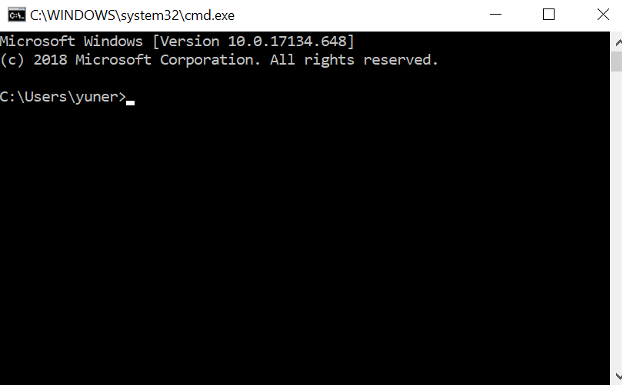

By default, the working directory of Command Prompt is your home folder, which is `C:\Users\YOUR_USRE_NAME\`. All your personal files fall under this folder most of the time. For example, your *Documents* folder is a sub-folder of this home folder (`C:\Users\YOUR_USRE_NAME\Documents`). Same for the *Downloads* folder (`C:\Users\YOUR_USRE_NAME\Downloads`) and *Desktop* (`C:\Users\YOUR_USRE_NAME\Desktop`).

You can use the command `cd FOLDER_NAME` to change the working directory, with a backslash `\` separating each folder. For example, if your want to access a folder *jmsc6116* on your desktop, you can use the command `cd Desktop\jmsc6116` to do so. If you want to go back to the folder one level up, type `cd ..`.

### Mac

Click on the search icon on the menu bar on the top right hand corner of your screen. Type terminal and launch Terminal.

[figure not shown]

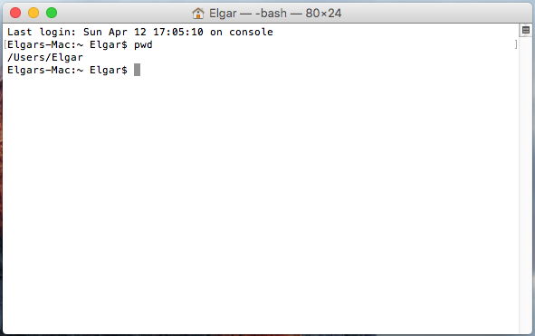

By default, the working directory of Terminal is your home folder, which is `/Users/YOUR_USER_NAME`. All your personal files fall under this folder most of the time. For example, your *Documents* folder is a sub-folder of this home folder (`/Users/YOUR_USER_NAME/Documents`). Same for the *Downloads* folder (`/Users/YOUR_USER_NAME/Downloads`) and *Desktop* (`/Users/YOUR_USER_NAME/Desktop`).

You can use the command `cd FOLDER_NAME` to change the working directory, with a slash `/` separating each folder. For example, if your want to access a folder *jmsc6116* on your desktop, you can use the command `cd Desktop/jmsc6116` to do so. If you want to go back to the folder one level up, type `cd ..`.

## Installing

You need these five things on your machine for RSelenium to run:

1. Chrome browser
2. Java Development Kit (JDK)
3. Selenium Server
4. Browser Driver
5. RSelenium

I assume all of you already have Chrome installed on your computer.

### JDK

RSelenium requires JDK to run. You can check whether you already have it by typing `javac -version` in the Command Prompt/Terminal. If you see `javac 16`, you can skip this part. This tutorial is based on JDK version 16. Other versions may work, but if you run into errors please intall JDK 16.

Download JDK [here](https://www.oracle.com/java/technologies/javase-jdk16-downloads.html). For Windows, download *jdk-16.0.1_windows-x64_bin.exe*. For Mac, download *jdk-16.0.1_osx-x64_bin.dmg*. Then proceed with the installation.

To check whether JDK is properly installed, type `javac -version` in the Command Prompt/Terminal. You should see `javac 16`.

### Selenium Server

Download Selenium Server [here](http://selenium-release.storage.googleapis.com/3.141/selenium-server-standalone-3.141.59.jar). Save it in a folder of your choice and remember the folder path, to which we refer as `SELENIUM_FOLDER` below.

### Browser Driver

The browser driver acts as a “middleman” between Selenium Server and the browser so that Selenium Server can control the browser. We’re using Chrome in this tutorial, but Selenium Server also supports a wide variety of browsers so if you’re interested in using other browsers you can look for the respective drivers.

First, check which version of Chrome you have:

[figure not shown]

Then, go [here](https://chromedriver.storage.googleapis.com/index.html) and look for the folder with the name corresponding to your Chrome’s version number. For example, if your Chrome version is *90.0.4430.24*, go to the folder *90.0.4430.24*. If you can’t find your version, choose the folder with the closest previous version, e.g. go to *90.0.4430.24* if you have *90.0.4430.85*. In the folder, download *chromedriver_win32.zip* for Windows, *chromedriver_mac64.zip* for Intel Mac or *chromedriver_mac64_m1.zip* for M1 Mac.

After downloading, unzip the file and save its content *chromedriver* in the same folder where you placed the Selenium Server file, i.e. `SELENIUM_FOLDER`.

### RSelenium

Open RStudio and install the package RSelenium:

```r
install.packages("RSelenium")
```

## Using RSelenium

To use RSelenium, you need to have Selenium Server up and running first.

Open Command Prompt/Terminal and switch to the folder where you saved the Selenium Server file and the browser driver:

```
cd SELENIUM_FOLDER
```

Then launch Selenium Server with the following command in Mac:

```
java -Dwebdriver.chrome.driver=chromedriver -jar selenium-server-standalone-3.141.59.jar -port 4444
```

in Windows:

```
java -Dwebdriver.chrome.driver=chromedriver.exe -jar selenium-server-standalone-3.141.59.jar -port 4444
```

If everything is working fine, your should see a bunch of text showing up with the last line being `Selenium Server is up and running on port 4444` (the screenshot below shows 4445 but yours should say 4444):

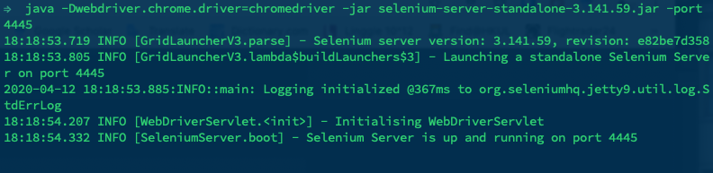

DO NOT close the Command Prompt/Terminal window while using RSelenium!

Open RStudio and run the following test commands:

```r
require(RSelenium)
rD <- remoteDriver(remoteServerAddr = "localhost", port = 4444L, browserName = "chrome")
rD$open()
rD$navigate("http://www.bbc.com")
```

If you’re running RSelenium for the first time on a Mac, you may encounter error. Please refer to the section below.

You should see a chrome browser window showing up and loading BBC’s website automatically:

[figure not shown]

### Special Note for Mac Users

You may encounter error with this dialog showing up when running RSelenium for the first time:

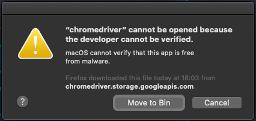

DO NOT click on *Move to Bin*! Cancel it instead.

Open up System Preferences and go to *Secutiry & Privacy*:

[figure not shown]

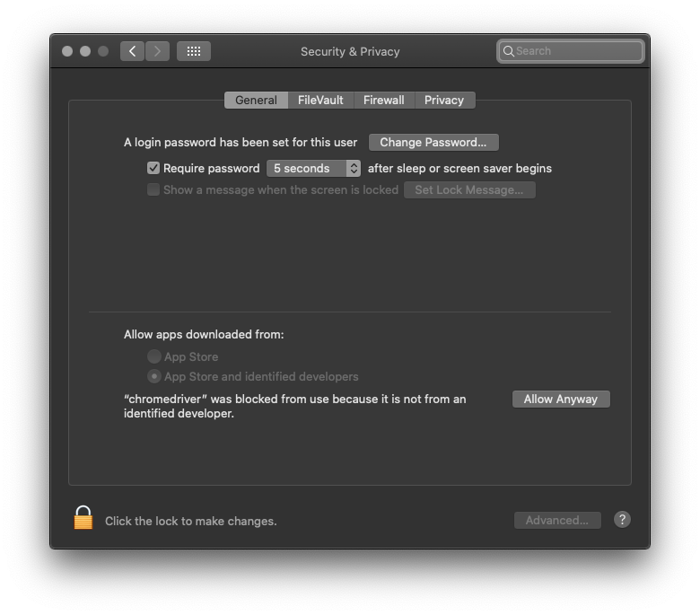

Click on *Allow Anyway*.

Go back to RStudio and run the test commands again. You’ll see this dialog popping up this time:

[figure not shown]

DO NOT click on *Move to Bin*! Click *Open*.

It should be working now. And no worries, this problem only shows up when you’re running RSelenium for the first time.

## Closing RSelenium

To close RSelenium properly, run the following command:

```r
rD$close
```

Afterwards, switch to the Command Prompt/Terminal window where Selenium Server is running and press the key combination Ctrl + C (same for both Windows and Mac). This will terminate Selenium Server. You can then close the Command Prompt/Terminal window.